# Лабораторная работа №3

Анализ трафика в Wireshark

Ко Антон Геннадьевич

antonkosakh@gmail.com

Российский университет дружбы народов

2026-03-17

# Информация

## Докладчик

- Ко Антон Геннадьевич
- студент
- Российский университет дружбы народов им. П. Лумумбы
- 1132221551@rudn.ru
- https://SenDerMen04.github.io/ru/

[figure not shown]

# Вводная часть

## Цель работы

Изучение посредством Wireshark кадров Ethernet, анализ PDU протоколов транспортного и прикладного уровней стека TCP/IP.

## Задание

1. MAC-адресация
   1. Изучение возможностей команды ipconfig для ОС типа Windows (ipconfig для систем типа Linux).
   2. Определение MAC-адреса устройства и его типа.
2. Анализ кадров канального уровня в Wireshark
   1. Установить на домашнем устройстве Wireshark.
   2. С помощью Wireshark захватить и проанализировать пакеты ARP и ICMP в части кадров канального уровня
3. Анализ протоколов транспортного уровня в Wireshark. С помощью Wireshark захватить и проанализировать пакеты HTTP, DNS в части заголовков и информации протоколов TCP, UDP, QUIC.
4. Анализ handshake протокола TCP в Wireshark.С помощью Wireshark проанализировать handshake протокола TCP.

# Выполнение лабораторной работы

# MAC-адресация

## MAC-адресация

С помощью команды `ipconfig` выведем информацию о текущем сетевом соединении.

Вывод команды `ipconfig`

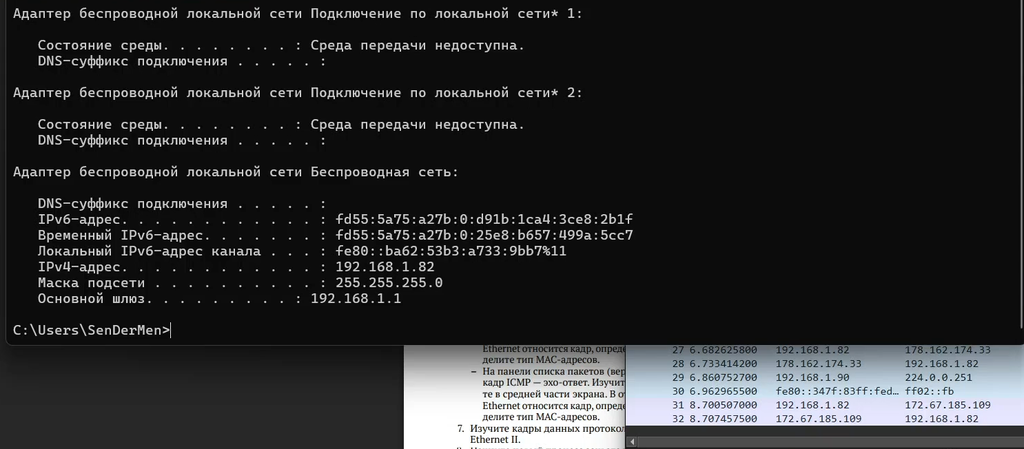

Вывод команды `ipconfig`

## MAC-адресация

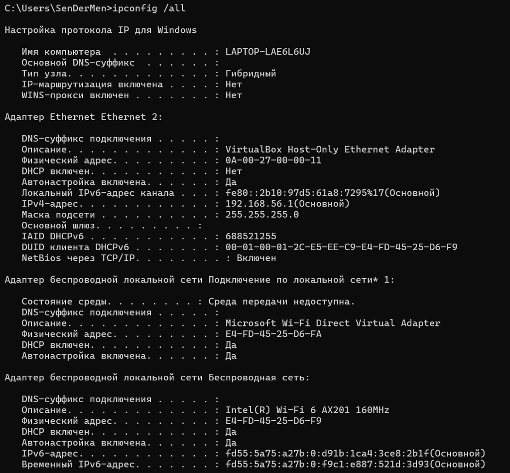

Использование опции `/all`

## MAC-адресация

Первые три байта E4:FD:45 в этом адресе соответствуют индентификатору производителя. Последние три байта 25:D6:F9 индентифицируют сетевой интерфейс.

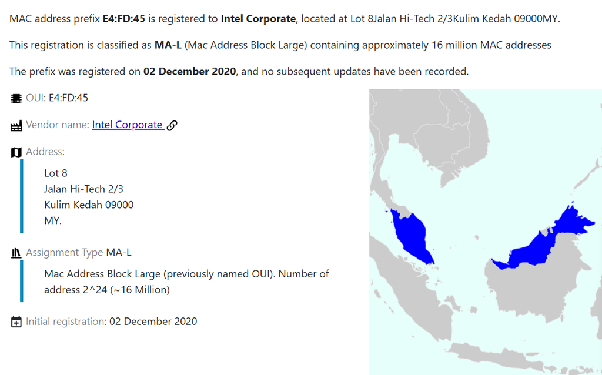

Демонстрация производителя сетевого оборудования

## MAC-адресация

# Анализ кадров канального уровня в Wireshark

Запустим wireshark и начнем захват трафика.

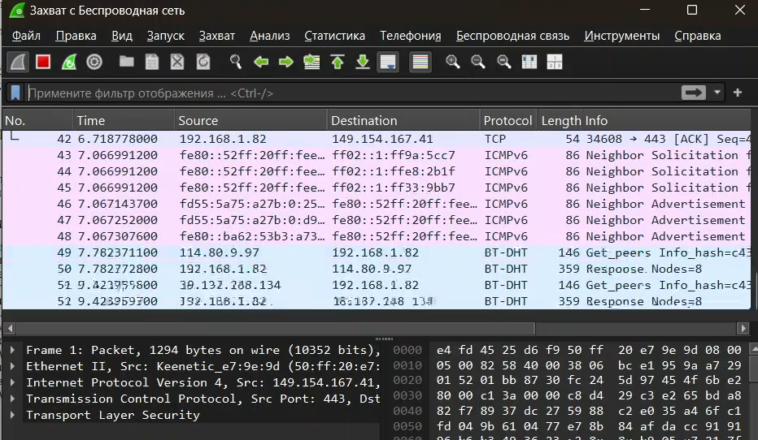

Захват трафика в wireshark

## Анализ кадров канального уровня в Wireshark

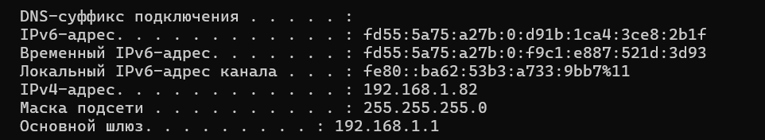

Определение IP-адреса устройства и шлюза по умолчанию

## Анализ кадров канального уровня в Wireshark

С помощью команды `ping 192.168.1.1` пропингуем шлюз по умолчанию.

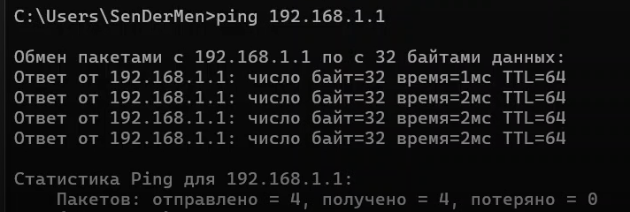

Пингование шлюза по умолчанию

## Анализ кадров канального уровня в Wireshark

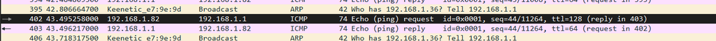

Кадр ICMP - эхо-запрос

## Анализ кадров канального уровня в Wireshark

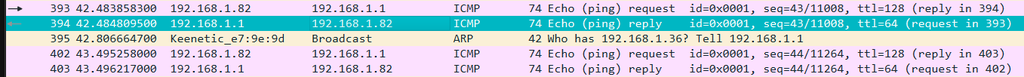

Кадр ICMP - эхо-ответ

## Анализ кадров канального уровня в Wireshark

Теперь начнём новый процесс захвата трафика и пропингуем сайт vk.com.

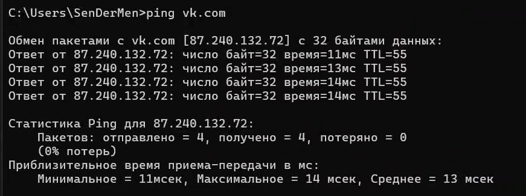

Пингование сайта vk.com

## Анализ кадров канального уровня в Wireshark

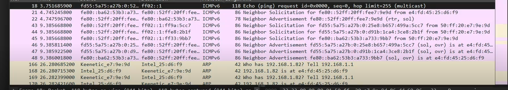

## Анализ кадров канального уровня в Wireshark

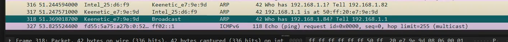

Пингование сайта vk.com. Кадр ARP - запрос

# Анализ протоколов транспортного уровня в Wireshark

## Анализ протоколов транспортного уровня в Wireshark

Порт источника задан случайно, выбором из непривелигированных и незанятых портов, и равен 56439, порт назначения равен 80 - это стандартный порт HTTP.

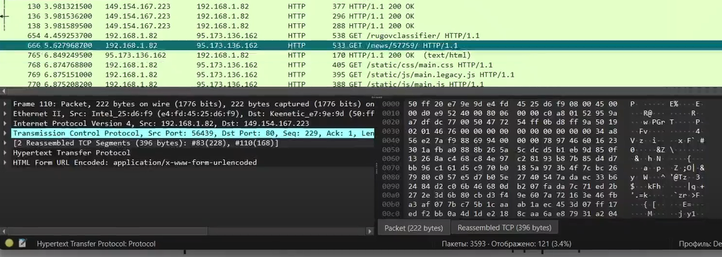

Запрос HTTP по протоколу TCP

## Анализ протоколов транспортного уровня в Wireshark

В случае ответа порты заданы наоборот, то есть источник - 80 порт, назначение - 56439.

## Анализ протоколов транспортного уровня в Wireshark

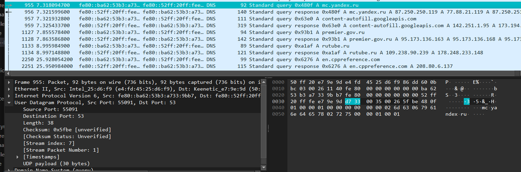

Запрос dns по протоколу UDP

## Анализ протоколов транспортного уровня в Wireshark

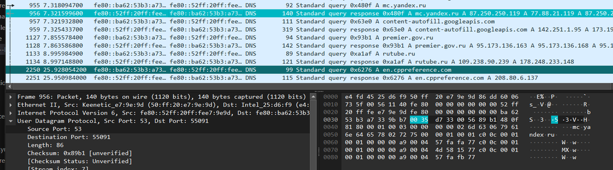

Ответ DNS по протоколу UDP

## Анализ протоколов транспортного уровня в Wireshark

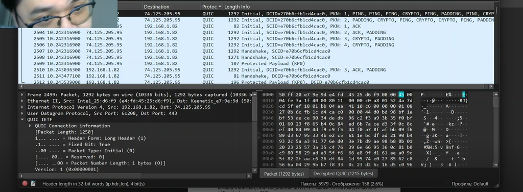

Запрос QUIC по протоколу UDP

## Анализ протоколов транспортного уровня в Wireshark

В случае ответа порты заданы наоборот, то есть источник - 443 порт, назначение - 61208.

## Анализ протоколов транспортного уровня в Wireshark

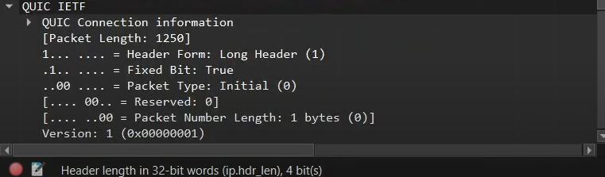

Вкладка QUIK IETF в случае запроса quik

# Анализ handshake протокола TCP в Wireshark

## Анализ handshake протокола TCP в Wireshark

Режим активного доступа. Во вкладке с флагами видно, что установлен бит SYN(Syn: set). Порядковый номер равен 3980370530.

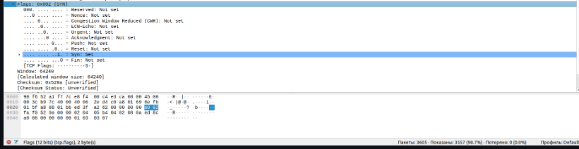

Первая ступень handshake протокола TCP

## Анализ handshake протокола TCP в Wireshark

Режим пассивного доступа. Во вкладке с флагами видно, что установлены биты SYN и ACK(Syn: set, Acknowldgment: set). Порядковый номер содержит значение ISSb и равен 452625189. Поле номер подтверждения равен значению ISSa, которое получил в предыдущем пакете, плюс 1, то есть 3980370531.

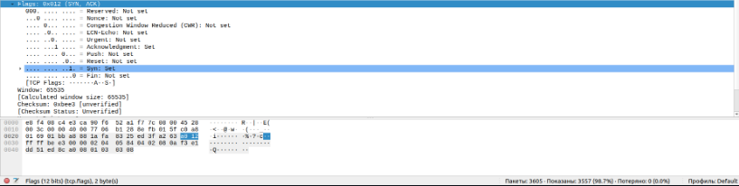

Вторая ступень handshake протокола TCP

## Анализ handshake протокола TCP в Wireshark

Завершение рукопожатия. Во вкладке с флагами видно, что установлен бит ACK(Acknowldgment: set). Порядковый номер равен ISSa+1 и равен 3980370531. Поле номер подтверждения равен значению ISSb, которое получил в предыдущем пакете, плюс 1, то есть 452625190.

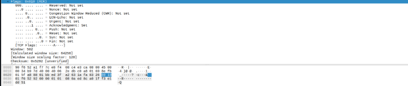

Третья ступень handshake протокола TCP

## Анализ handshake протокола TCP в Wireshark

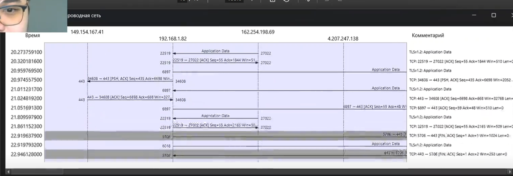

График потока

# Заключение

## Выводы

В результате выполнения лабораторной работы посредством Wireshark были изучены кадры Ethernet, а также проанализированы PDU протоколы транспортного и прикладного уровней стека TCP/IP.